# Reproducible Research Project 1

Robert Nine

March 5, 2016

## Introduction

This is project 1 of the Coursera Reproducible Research course.

It makes use of data from a personal activity monitoring device, which collected data at 5 minute intervals through out the day. The data consists of two months of data from an anonymous individual collected during the months of October and November, 2012.

The data for this assignment was downloaded from the course web site:

```
Dataset: https://d396qusza40orc.cloudfront.net/repdata/data/activity.zip
```

The variables in this dataset include:

```
steps: Number of steps taking in a 5-minute interval (missing values are coded as NA)
date: The date on which the measurement was taken in YYYY-MM-DD format
interval: Identifier for the 5-minute interval in which measurement was taken
```

The original dataset was stored in a comma-separated-value (CSV) file with a total of 17,568 observations.

## Loading and preprocessing the data

```r
library(ggplot2)
library(lubridate)
library(dplyr)
```

### Load the data (i.e. read.csv())

Check to see if the activity.csv files exists, if not unzip it from the distribution file.

```r
if(!file.exists('activity.csv')){
    unzip('activity.zip')
}
data <- read.csv("activity.csv", header = TRUE, sep = ',', colClasses = c("numeric", "character","integer"))
```

### Process/transform the data (if necessary) into a format suitable for your analysis

Convert the date string into a date object.

```r
data$date <- ymd(data$date)
```

## What is mean total number of steps taken per day?

At this stage of the analysis we are ignoring missing values.

### Calculate the total number of steps taken per day

```r
stepsPerDay <- data %>% filter(!is.na(steps)) %>%
  group_by(date) %>% summarize(steps = sum(steps)) %>% print
```

```
## Source: local data frame [53 x 2]
##
##          date steps
##        (time) (dbl)
## 1  2012-10-02   126
## 2  2012-10-03 11352
## 3  2012-10-04 12116
## 4  2012-10-05 13294
## 5  2012-10-06 15420
## 6  2012-10-07 11015
## 7  2012-10-09 12811
## 8  2012-10-10  9900
## 9  2012-10-11 10304
## 10 2012-10-12 17382
## ..        ...   ...
```

### Make a histogram of the total number of steps taken each day

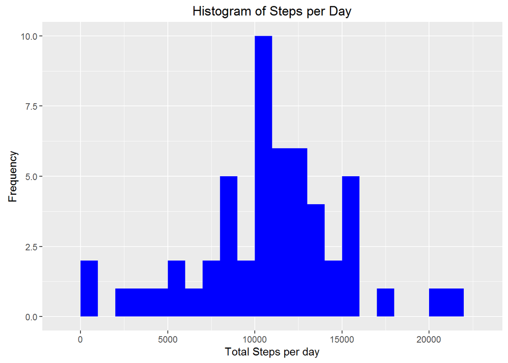

```r
ggplot(stepsPerDay, aes(x = steps)) + geom_histogram(fill = "blue", binwidth = 1000) +
  labs(title = "Histogram of Steps per Day", x = "Total Steps per day", y = "Frequency")
```

### Calculate and report the mean and median of the total number of steps taken per day

```r
meanStepsPerDay <- mean(stepsPerDay$steps, na.rm = TRUE)
medianStepsPerDay <- median(stepsPerDay$steps, na.rm = TRUE)
```

MEAN: 10766.19

MEDIAN: 10765.00

## What is the average daily activity pattern?

```r
averageStepsPerInterval <- data %>% filter(!is.na(steps)) %>%
  group_by(interval) %>% summarize(steps = mean(steps))
```

## Make a time series plot (i.e. type = “l”) of the 5-minute interval (x-axis) and the average number of steps taken, averaged across all days (y-axis)

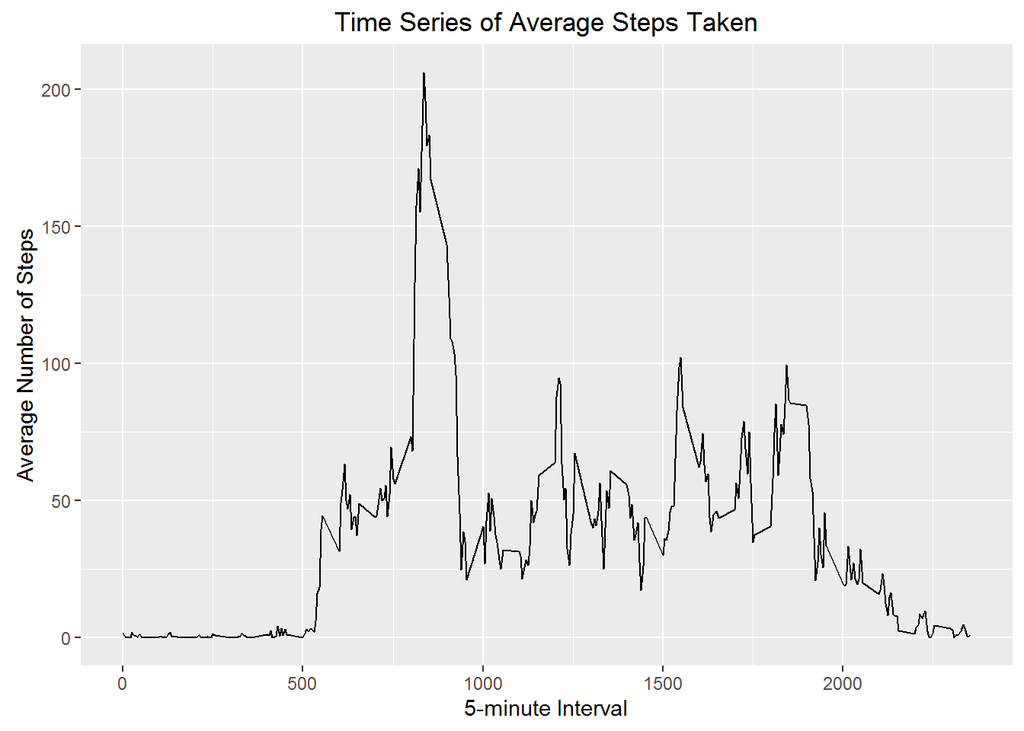

```r
ggplot(data=averageStepsPerInterval, aes(x=interval, y=steps)) + geom_line() +
  labs(title = "Time Series of Average Steps Taken", x = "5-minute Interval",
       y = "Average Number of Steps")
```

## Which 5-minute interval, on average across all the days in the dataset, contains the maximum number of steps?

```r
maxSteps <- which.max(averageStepsPerInterval$steps)
maxStepsTime <-  gsub("([0-9]{1,2})([0-9]{2})", "\\1:\\2", averageStepsPerInterval[maxSteps,'interval'])
```

Maxium number of steps occurred at 8:35

## Imputing missing values

There are a number of days/intervals where there are missing values (coded as NA). The presence of missing days may introduce bias into some calculations or summaries of the data.

### Calculate and report the total number of missing values in the dataset (i.e. the total number of rows with NAs)

```r
numMissingValues <- length(which(is.na(data$steps)))
```

Total number of missing values is 2304

Our approach for dealing with missing data is to average the number of steps in the same 5 minute interval.

We will create a new dataset that is equal to the original dataset but with the missing data filled in.

```r
imputedData <- data

nas <- is.na(imputedData$steps)

avg_interval <- tapply(imputedData$steps, imputedData$interval, mean, na.rm=TRUE, simplify=TRUE)

imputedData$steps[nas] <- avg_interval[as.character(imputedData$interval[nas])]
```

Originally there were 2304 missing values. Now we check again

```r
length(which(is.na(imputedData$steps)))
```

```
## [1] 0
```